[Dewey research project](https://davidchivers.github.io/davidchivers.co.uk/dewey/)

# Dewey: Green Book source consistency

19 October 2026 | Exposure, mixing and attitudes

Dark mode

19 October 2026. Complete result note, prospective protocol, separate post-first-run correction, construction log and independent review. Adds a source-version comparison only; original literature, historical rights/date gates and contemporary empirical findings are unchanged. No listing-level data, coordinates or match tables. This is a documentation snapshot, not a Project upload or a validated sampling frame.

# Green Book data: two versions are not a nested sample

19 October 2026. Complete public-source comparison, not a historical-modern linkage, a discrimination estimate or a new exposure result.

## Main conclusion

**Do not combine the two public NYPL 1947 derivatives or choose the larger one as a verified historical sampling frame.** They overlap substantially, but each contains source-image regions absent from the other; shared entries also differ in city, category and coordinate fields. This resolves the earlier uncertainty about whether the 796-row file is simply a subset of the 1,056-row file under the inspected exact source-region key. It does not resolve why the versions diverged, which transcription is correct or whether either covers a complete edition.

The Green Book direction remains **narrowed to an outcome-blind historical site feasibility study**, separate from the main contemporary-mixing paper. The North Carolina inventory remains the strongest bounded lead, conditional on obtaining its master spreadsheet, exact reuse terms and dated histories. Neither NYPL derivative contains North Carolina-labelled entries. No modern POIs were accessed or matched in this audit.

## What was compared

The first source is the 1947 GeoJSON in NYPL’s `greenbooks` repository. The second is the 1947 GeoJSON supplied with its separate `greenbook-map` interface; that file has 797 entries, of which one is null. The third is the 796-row display JSON produced for that interface. The repositories describe an experimental interface and OCR/Scribe corrections, not a harmonized longitudinal establishment panel. Both inspected structured-data repositories carry CC0 licences. This audit does not extend that statement to all linked images or to the separate NC map layer. [NYPL text/data repository](https://github.com/NYPL-publicdomain/greenbooks); [NYPL map repository](https://github.com/NYPL-publicdomain/greenbook-map).

All three files were fetched at the previously recorded commits and matched their earlier SHA-256 hashes. They were parsed in local process memory only. No listing, name, address, coordinate, source-region identifier or row-level match file was saved or transmitted. The public outputs are aggregate checks.

## Results

| Check | Result | Interpretation |
| --- | --- | --- |
| Non-null source entries | 1,056 versus 796 | Two different derivatives, not two years |
| Exact shared `(year, image, region)` keys | 672 | Unique in both sources; a source-location match, not verified firm identity |
| Entries without that match | 384 versus 124 | Neither source-key set contains the other |
| Exact normalized name/address/city/state/year matches | 528 | All are among the 672 source-region pairs |
| Source-region pairs with different city labels | 143 / 672 | Difference remains after case/whitespace normalization |
| Source-region pairs with coordinates over 1 km apart | 78 / 672 (11.6%) | A material version disagreement, not measured geocoding error |
| Source-region pairs with identical coordinates | 594 / 672 | Agreement is not proof that the location is historically correct |
| States represented | The same 23 labels | Neither includes NC, NY or IL; national completeness is unverified |

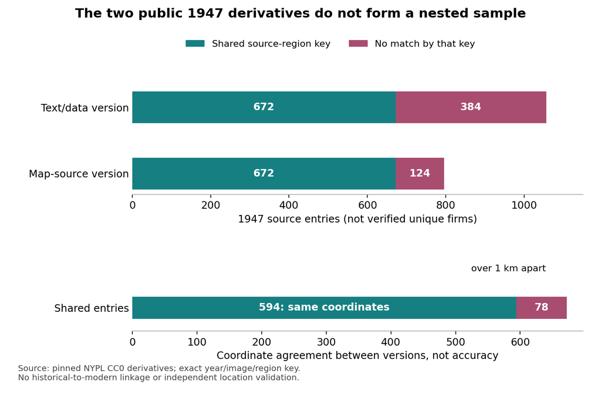

The two 1947 sources share 672 source-region keys, with 384 and 124 unmatched entries; 78 of the 672 shared keys have coordinate differences above one kilometre.

The exact name/address/city/state/year key excludes missing components and does not expand abbreviations or remove punctuation. Nine entries in the larger source and eight in the map source lack a complete key; the larger source also has one duplicated text key spanning two rows. Duplicate groups are not joined many-to-many. The 528 text pairs agree with the source-region pairs, but this agreement still does not establish historical business identity or continuity.

Category differences are not entirely cosmetic. All 672 shared source-region entries have different raw category strings; 651 remain different after case/whitespace normalization. Applying the inspected parser’s category rules to both sides yields disjoint possible output sets for 179 pairs. This is a coding-version diagnostic, **not** evidence that establishments changed service type. We have not checked the original page images to decide which category or location is correct.

State counts also differ non-uniformly. California has 154 versus 74 entries, whereas Mississippi has 127 versus 161. Therefore a uniform scaling factor cannot reconcile these source frames. These are derivative counts, not estimates of historical business prevalence or discriminatory access.

## Can the map’s display conversion be reproduced?

The map-source file uses the misspelled key `geomotry`; the inspected Python 2 converter explicitly expects that spelling. Feeding the other GeoJSON to that literal predicate would reject all 1,056 features. That is a schema compatibility issue, **not an explanation of the two historical frames**. [Pinned converter](https://github.com/NYPL-publicdomain/greenbook-map/blob/4e5520002ee8ffcf45a1df8d81a0f1c2293ca79d/scripts/parse_geojson.py).

For the map’s own input, all seven non-category fields agree with the display file in the same 796-row order, including the longitude/latitude reversal. The 790 unambiguous category rows reproduce exactly as a multiset. Six category strings match more than one substring rule in the original Python 2 dictionary. Each displayed category is compatible with the applicable rules, but the original dictionary order was not verified. We therefore report **row-wise compatibility, not exact deterministic reproduction of all 796 category assignments**. No downloaded script was executed.

## What this changes for the research design

1. **Keep historical coverage separate from modern survival.** An absent row in one derivative is not a business closure. Nonlisting is not evidence of discrimination, and a listed business need not have had a mixed crowd.
2. **Do not snap uncertain historical coordinates to the nearest modern POI.** First resolve original edition/page evidence and address changes. A shared source-image region is not an address-validated parcel or persistent firm.
3. **Obtain the NC inventory before choosing a pilot denominator.** Retain demolished and unknown sites, distinguish firms from sites, and seek dated 2017-2019 operating states. The previously inspected 2024 status labels cannot supply these histories. The earlier 317-resource versus 327-business discrepancy remains unresolved.
4. **Keep the ranking unchanged.** This is useful feasibility evidence and a reason to avoid a quick national merge, not a new publication result. The main project still needs the upstream construction audit and Eren’s separately authorized category/area/venue decomposition.

No access request, colleague message, NC feature download, source-image review, new restricted-file read, linkage or regression was undertaken here. The earlier historical and causal-design gates remain binding.

## Reproducibility and corrections

The prospective protocol fixes the match keys, distance bands and output scope. The first pass exposed a state-label reporting bug: full state names were placed in the residual group by an abbreviation-only lookup. The corrected lookup recognizes all 50 states and DC and leaves unknown labels explicit. The original receipt and code snapshot are retained. A separate dated addendum records that repair and the post-result category-compatibility diagnostic; it does not change the matching rules.

The corrected comparison and a fresh rerun took 0.60 and 0.74 seconds. All deterministic results, input identities, supporting-source identities and local code/protocol hashes agree. The 26 current synthetic tests cover duplicate multiplicities, incomplete keys, Unicode, ambiguous categories, state labels, coordinate order, distance boundaries and normalized category diagnostics. Independent review and actual delivery are recorded separately, not inferred from this note.

This note supersedes only the earlier claim that the relation between the two 1947 derivatives had not been tested. It preserves the prior source inventory, literature assessment, NC rights/history gaps and original protocols. Published documents and Project sources are snapshots, not live data access.

# Green Book source reconciliation

Recorded 19 October 2026 before the record comparison. This is a public-source consistency audit under rank 3, not a historical-modern linkage or an exposure regression. The existing NC inventory, dated-status and file-specific rights requirements remain unchanged.

## Scope and inputs

Use only three already inspected CC0 files at the commits and SHA256 values in `output/green_book_feasibility_20261019/nypl_schema_inventory.json`:

- `greenbooks/geojson/1947.geojson` (the 1,056-feature derivative).
- `greenbook-map/scripts/data/1947.geojson` (797 entries, one null).
- `greenbook-map/data/greenbook_1947.json` (796 display rows).

Fetch bytes into memory; require exact earlier hashes before parsing. Inspect and fingerprint the two pinned repository licences and the pinned `parse_geojson.py`, but do not execute downloaded code. No listing, address, coordinate, image-region identifier, row hash or matched-pair file is saved or returned to an assistant. No 1956 data, scans, NC layer features, modern POIs, proprietary files or additional historical datasets are included.

## Comparisons fixed before execution

1. Reimplement the inspected display conversion locally: non-null features with `geomotry` and properties, the eight declared output fields, longitude/latitude reversal and the documented category map. Compare row sequence and multiset with the display file. Check category-substring ambiguity separately: Python 2 dictionary iteration did not promise a stable first-match order. Do not silently impose an ordering if two distinct category outputs are possible.
2. Compare the two GeoJSON sources using two independent exact-key schemes. The source-region key is `(year, image_id, image_region)` with nonempty fields and exact JSON region representation. The text key is `(year, name, address, city, state)` after Unicode NFKC, case folding and whitespace normalization only. Require all fields. Do not strip street numbers, punctuation or abbreviations and do not fuzzy-match.
3. For each scheme, report missing keys, duplicate keys/rows, multiset overlap and uniquely paired rows. Never form Cartesian joins of duplicate keys. Compare the two sets of uniquely paired indices to quantify agreement; neither key is assumed to identify a historical firm.
4. Among unique source-region pairs, count field disagreements and coordinate displacement in predeclared bands: exact, (0,25m], (25,100m], (100,1000m], over 1000m, or invalid. These are differences between derivatives, not geolocation accuracy against ground truth. Report label-normalized state coverage for both sources and unmatched rows, not listing-level outputs.
5. Report exact full-feature multiset overlap after aligning the geometry key and excluding only the map-source-only `scribe_url` property. Separately retain the less restrictive comparisons above; do not force counts to fit.

## Verification and decision

Use synthetic cases for missing keys, duplicate multiplicities, Unicode, category ambiguity, geometry spelling, coordinate order, row permutation and distance boundaries. Run the real public-source comparison twice; compare all deterministic results and input/code/protocol hashes. A focused independent review checks parser equivalence and whether conclusions exceed the evidence.

The audit may resolve a technical source-version discrepancy. It cannot establish complete edition coverage, national coverage, historical business identity, discrimination, closure, survival or present-day mixing. If differences remain, retain them explicitly rather than manufacture a bridge. Any publication uses only reviewed aggregate diagnostics and documentation.

# Diagnostic corrections after the first public-source pass

19 October 2026. The original comparison protocol and first-run receipt are retained, not rewritten. The first run took 1.82 seconds and revealed:

- The state summary recognized two-letter codes only. All source values were consequently placed in `other_or_missing`. That output is a reporting bug, not evidence of absent geography. Add a fixed 50-state/DC name-to-code dictionary and synthetic tests, including Texas. Retain unknown labels in the explicit residual group. No state is inferred from coordinates.
- Six map-source category strings match more than one distinct output in the original Python 2 dictionary-based substring map. The unambiguous 790-row subset matches the display multiset exactly; a deterministic 796-row reproduction must not be claimed. Add a separate row-order check that all seven non-category fields agree and that each displayed category belongs to the permitted set for that row. Even if this passes, the original Python 2 dictionary ordering remains unverified.
- Add normalized-string and parser-category-set disagreement counts for the already prespecified source-region pairs. Raw category disagreement alone may reflect capitalization/format changes. This explanatory diagnostic does not replace raw-field counts or change the match keys.

These are transparent post-result reporting additions, not new linkage rules, historical outcomes or an attempt to make the two source frames agree. Save the initial code and receipt. Run the corrected code twice; retain exact input hashes and distinguish these reruns from the initial pass.

# Construction log: Green Book derivative consistency

19 October 2026. Local public-source audit only. No restricted files, NC layer features or source images were read. No row-level public records were saved.

## Inputs and scope

The prior allowlist is `output/green_book_feasibility_20261019/nypl_schema_inventory.json`. Only its three 1947 files were processed; the 1956 derivative was excluded. Both pinned CC0 licence texts and the pinned converter were read/fingerprinted but the remote converter was not executed. The run refuses a data hash or byte-length mismatch and bounds each download to five million bytes. Responses are parsed in memory. The earlier inventory, protocol and code hashes are stored with each aggregate-only run receipt.

| Input | SHA-256 |
| --- | --- |
| `greenbooks/geojson/1947.geojson` | `30a75aef82df2107d9ef1e3518efcaeb281d2b055903b6d58b4df44c2354c804` |
| `greenbook-map/scripts/data/1947.geojson` | `0bff94b57c3d6fc507b9c9f05d5e7ea75537025713812696641e1d5daf487259` |
| `greenbook-map/data/greenbook_1947.json` | `5094852115717693fd8bab259a18f12f40c0b510505aa88ad8d92940f3f57a34` |

The exact immutable URLs, byte counts, supporting-source hashes and resolved URLs are in the safe run JSON. Repository commits are `45328936f4984830f6916922238ed5e8c4e024b6` and `4e5520002ee8ffcf45a1df8d81a0f1c2293ca79d` respectively.

## Transformations

The runner validates feature containers and the two geometry spellings, excluding the one null map-source entry. It does not delete non-null records. The source key retains exact JSON representations of year, image ID and image region. The separate text key uses Unicode NFKC, case folding and whitespace normalization only. Missing components invalidate that key. Groups are counted before joining: only keys unique on both sides form one-to-one diagnostic pairs; multiplicity is retained in multiset overlap.

Coordinates must be finite numeric Point longitude/latitude pairs in valid ranges. Haversine displacement uses radius 6,371,008.8 metres and the frozen bands. Validity and agreement are not independently validated historical location. State counts map full names or two-letter labels to a fixed 50-state/DC dictionary. Unknown values remain a labelled residual.

Full-feature equality aligns the geometry spelling and removes only the map-specific `scribe_url` property. All remaining property differences are retained. Category possibilities use the inspected substring map, not a new substantive classification. Ambiguous outputs are not selected to fit data. The separate compatibility check compares each row’s seven non-category fields in order and asks whether its displayed category is permitted. It does not recover the actual original Python 2 dictionary order.

## Execution and correction history

- Initial execution: 1.8196895 seconds; `first_run.json`, SHA-256 `bd4fa4736d75c9c805a2ec46e6cbe889e07020bed5c999f33766aee9c7a2e274`. The first 19 synthetic tests passed. State counts were misreported because the lookup recognized abbreviations only. This is corrected, not suppressed. The code is retained as `audit_code_first_run.py` alongside that receipt.
- Dated addendum: `docs/protocols/green_book_source_reconciliation_addendum_20261019.md`. State-label fix and compatibility diagnostics were recorded before reruns. The original protocol and first-run outputs remain unchanged.
- Corrected run: 0.5963201 seconds; `corrected_run.json`, SHA-256 `f7a152776dc4e95f21976546692fc03f8171ec640d83393c21c0124865d5881e`.
- Repeat: 0.7424236 seconds; `replication_run.json`, SHA-256 `f0322cdd27dc028a0356abf50d5008e66237f4f5a812fd81f5342cf5b627468d`. All deterministic result fields and source identities match. Times and timestamps necessarily differ. The 23 then-current synthetic tests pass.
- Independent review requested direct normalized-field/category-set coverage. Three further regression tests were added without changing the analysis runner or empirical results. All 26 current synthetic tests pass. The execution receipts omit addendum/test hashes; the separate documentation manifest binds both without altering those preserved receipts.

Both corrected receipts identify the same runner and original protocol. The documentation manifest additionally fingerprints the addendum, tests, construction log, result note, original inventory and independent review. No empirical income measure, modern dataset or regression was rerun.

## Reproduction

From the project root, with Python 3 standard library and network access to the public pinned sources:

```powershell
python -B -m unittest discover -s code/analysis -p test_green_book_sources.py
python -B code/analysis/audit_green_book_sources.py --output output/green_book_source_reconciliation_20261019/new_replication.json
```

Use a new output name: the runner refuses to overwrite an existing receipt. The prior inventory must be present at the documented project-relative path. The plotting/publication helper additionally uses the existing Matplotlib and Pandoc installations; no new package or service was purchased/installed.

## Interpretation and publication boundary

Only national/source-level counts, field-disagreement counts, state counts, hashes and documentation are eligible for publication. No names, addresses, coordinate values, source-region values, row hashes or match tables are exported. Exact source-region equality is not firm identity. The unverified original parser ordering is not called reproduced. No completeness, historical ground truth, closure, discrimination or modern survival inference follows.

Website, Space and Project delivery have distinct receipts. A sourcebook prepared locally is not a Project upload. The Project’s earlier 40-file limit and pending consolidation decision are not bypassed by this audit.

# Independent review: Green Book source reconciliation

19 October 2026. Focused review of the corrected snapshot, not new research. Main retains decisions and integration. No main code, tests, protocol, receipts, status, or shared records were edited. This note is the reviewer’s only write.

## Findings

No blocking correctness finding for the three pinned inputs and the limited source-consistency claims. The original state-reporting bug is fixed, not an open finding against the corrected code. The preserved initial code’s SHA256 matches the first-run receipt; its defective state totals remain audit history.

1. **[P3] Corrected receipts do not bind the full corrective specification or test snapshot.** `code/analysis/audit_green_book_sources.py:325` fingerprints the original protocol, inventory and analysis code only; `output/green_book_source_reconciliation_20261019/corrected_run.json:46` consequently omits the corrective addendum and test file. The same applies to the replication receipt. The addendum explicitly changes reporting and verification requirements (`docs/protocols/green_book_source_reconciliation_addendum_20261019.md:11`). Future receipts should include those two hashes, or link a complete manifest. This is a provenance gap, not a demonstrated computational error or proof the addendum was written late. Hashes recorded below identify the reviewed snapshot; they cannot establish its pre-execution timing. Retain existing receipts rather than silently replacing them.
2. **[P3] New normalized-disagreement diagnostics need direct regression tests.** `code/analysis/audit_green_book_sources.py:238` adds normalized field counts and distinct-versus-disjoint category-output set counts. The added tests at `code/analysis/test_green_book_sources.py:94` cover state aliases and display compatibility, but not these diagnostics directly. Recommended synthetic cases: raw-only capitalization/whitespace differences; unequal category sets with a nonempty intersection; disjoint category sets. All three passed my independent in-memory checks, and the real aggregate counts independently reconcile. This is a regression-coverage gap, not a current-result discrepancy.

## Matching and duplicate semantics

- `code/analysis/audit_green_book_sources.py:157` (`match_summary`) correctly groups nonmissing keys, counts all rows in duplicate-key groups, computes multiset-key overlap as the sum of minimum multiplicities, and forms a pair only when the key occurs exactly once on each side. No Cartesian duplicate expansion or arbitrary duplicate resolution occurs. Rows without a unique pair include missing, absent, and ambiguous keys; this is not the same quantity as multiset-unmatched rows.
- Independently reproduced: 672 unique source-region pairs, 528 unique text pairs, pair intersection 528, region-only pairs 144, text-only pairs zero, and no conflicting partner among rows linked by both schemes. Region keys have no missing/duplicate rows. Text keys have 9/8 missing rows and one two-row duplicate group on the 1,056-row side, none on the 796-row side.
- The source-region key preserves JSON value/type distinctions; text matching uses only NFKC, case folding and whitespace normalization. State aliases are applied to coverage reporting, not silently added to the text-match rule. The corrected state dictionary covers 50 states plus DC, including Vermont.
- Independent checks reproduce both complete state-count dictionaries and the unmatched dictionaries. Both derivatives contain 23 observed state labels; neither contains NC, NY or IL under the corrected label interpretation. This is a statement about these pinned derivatives, not historical absence of listings or businesses in those states.

## Parser equivalence and evidence limits

- The pinned original parser was fetched and inspected as text only, with its SHA256 checked against the receipt. No downloaded code was executed. Its validity predicate requires `geomotry`, its seven non-category fields match the local conversion, and its category rule is first substring match under one Python 2 dictionary iteration order. The correctly spelled derivative would produce zero rows under that literal predicate; this is not evidence that its 1,056 features are invalid historical observations.
- Independent check: all 796 nonnull map-source features align in sequence with the display’s seven non-category fields; all display categories belong to their row’s possible output set. Six rows have multiple distinct outputs. The unambiguous 790-row multiset matches. Retain the corrected receipt’s `every_row_individually_compatible=true` and `original_python2_dictionary_order_verified=false`; do not call this exact deterministic 796-row parser reproduction.
- Additional bounded check: the ambiguous rows involve two relevant mapping keys. Of their two relative orders, exactly one satisfies all six stored choices simultaneously. Thus there is no contradiction requiring different key orders for different rows. This proves existence of a compatible shared order only, not the actual historical interpreter/hash configuration or production process. The code’s narrower, explicitly individual compatibility claim at `code/analysis/audit_green_book_sources.py:108` (`display_compatibility`) is appropriately labeled.
- The two keys are different matching rules, not independent historical evidence. The display and map-source files are derivative relatives; their agreement cannot independently validate transcription, business identity, geocoding, edition completeness or historical patronage. Read “independent” in `docs/protocols/green_book_source_reconciliation_20261019.md:33` as separate computational schemes only, not independent provenance.
- Among 672 region pairs: raw categories disagree in all 672; normalized categories disagree in 651; possible category-output sets differ in 181 and are disjoint in 179. Names, addresses and states agree; cities disagree in 143 even after normalization. Do not interpret category-set intersection as verified historical sector agreement.
- Independently reproduced coordinate bands: 594 exact and 78 over 1,000 m, zero in the intervening bands and zero invalid. These compare derivatives, not either derivative against a ground-truth location. Full-feature overlap after geometry-key alignment and removing `scribe_url` is zero; ubiquitous property differences make that compatible with substantial key overlap.
- The 260 net row-count difference is not 260 identified additions, omissions, closures or surviving firms. Region matching leaves 384 versus 124 unpaired rows, so the smaller source is not a subset under that exact key. Neither key defines an establishment. Duplicate coordinates also do not identify duplicate firms. The protocol’s historical-inference limits at `docs/protocols/green_book_source_reconciliation_20261019.md:60` and the addendum are appropriately cautious. I found no overreaching historical-frame conclusion in these reviewed documents.

## Exact verification scope

Read repository/project AGENTS, research-style guidance, project status, README, memory and DATA_POLICY for orientation, then the named protocol, analysis/tests, safe inventory, first-run receipt, corrective addendum and both corrected receipts. Restricted inputs were neither opened nor processed.

- Ran `python -B -m unittest -v test_green_book_sources`: all 23 final tests pass. The initial 19-test snapshot also passed before the correction arrived; that is not the basis of the final verdict.
- Fetched exactly the three approved 1947 listing-data files into process memory; verified all lengths and SHA256 values against the inventory before JSON parsing. No 1956 data, scans, NC layer, modern POIs or restricted files were fetched. Also inspected the already pinned parser as text, never code. Did not separately re-fetch or legally assess the licence texts.
- Wrote separate in-memory calculations for key groups/pairs, raw/normalized disagreements, category-output sets, display compatibility and shared-order existence, state coverage/unmatched coverage, coordinate bands and full- feature multiset overlap. All checked aggregates agree with corrected output.
- Separately called the reviewed local `audit()` in memory, not its writing `run()` entry point: the entire result object equals the corrected receipt. Corrected and replication receipts agree on every top-level field except timestamp and elapsed time, including all deterministic results, input receipts, supporting-source receipts and recorded local hashes.
- Ran 300 additional seeded synthetic duplicate/missing-key cases against independently constructed pair/multiplicity expectations, plus the three normalized/category diagnostics described above: all pass.
- No listing rows, addresses, coordinates, identifiers, row hashes or matched pairs were returned or persisted. No remote code, contacts, publication, restricted-data operation or wider research was performed. Python used `-B` to avoid bytecode writes. All ad hoc check code remained in process memory.

## Reviewed fingerprints

SHA256 values, captured after the corrected files arrived:

```
audit_green_book_sources.py
939cd8de35b49beb842c2b3863e86d261b828652d0395bb24640054478941bbd
test_green_book_sources.py
f8d31c72ced028216c882c13d6c24d5212f6bf698327fbab252d785b3017c4b2
green_book_source_reconciliation_20261019.md
c1cc05314aacd1f6f836c87dff11dd4ca5f86292d3921d8c01509acb3fb02d2f
green_book_source_reconciliation_addendum_20261019.md
cfa456c7727062a7b7435f998eefe783b7cfc3e251eb7002633eacf644907c33
nypl_schema_inventory.json
d28628c62747309e86e19db37b69865d5a7109f249c06969a137725b4b33ed1b
first_run.json
bd4fa4736d75c9c805a2ec46e6cbe889e07020bed5c999f33766aee9c7a2e274
corrected_run.json
f7a152776dc4e95f21976546692fc03f8171ec640d83393c21c0124865d5881e
replication_run.json
f0322cdd27dc028a0356abf50d5008e66237f4f5a812fd81f5342cf5b627468d
```

The corrected code, original protocol and inventory match the hashes recorded in both corrected receipts. This review certifies only the inspected snapshot and computational scope, not unreviewed future edits or historical validity.

## Scoped final follow-up

19 October 2026, after the three requested regression tests were added. The findings above retain the original review history; their current status is updated here. Source-label references throughout this authored review are project-relative and contain no private/local absolute paths.

- **P3 regression coverage fixed.** Inspected the three new direct tests in `code/analysis/test_green_book_sources.py:121` (raw versus normalized disagreement), `code/analysis/test_green_book_sources.py:132` (unequal but intersecting category-output sets), and `code/analysis/test_green_book_sources.py:139` (disjoint sets). They assert the distinctions requested in finding 2. Independently reran `python -B -m unittest -v test_green_book_sources`: all 26 tests pass (`Ran 26 tests in 0.002s`, `OK`). Finding 2 is closed for this snapshot.
- **P3 receipt gap: separate-manifest mitigation pending construction.** The proposed `documentation_manifest.json` will mitigate finding 1 once built and verified to bind the corrective addendum and the current test file, while retaining the original empirical receipts unchanged. This is a separate documentation-snapshot binding, not a retroactive change to those receipts or proof of pre-execution timing. I did not inspect a built manifest in this narrow follow-up and do not mark that mitigation verified.
- Current test-file SHA256: `e545e82db872897cf7dff2b7978cda3d7a65c87554dfff2f58941b1a61db9be7`. The earlier test fingerprint above remains the historical 23-test snapshot.
- This follow-up inspected the local tests and this review only, reran the synthetic suite, and changed only this review. It did not rerun the public- source comparison, fetch listing data, inspect publication live, contact anyone, or modify the runner, protocols, empirical receipts or other files. Earlier aggregate verification and historical-inference limits retain exactly their original scope. No new blocking finding.

## Downloads

[Complete dated audit and methods sourcebook](https://davidchivers.github.io/davidchivers.co.uk/dewey/assets/Dewey_Green_Book_Source_Audit_20261019_sourcebook.html) | [Aggregate diagnostics](https://davidchivers.github.io/davidchivers.co.uk/dewey/assets/green_book_source_diagnostics.json) | [Replication code, protocol and input metadata](https://davidchivers.github.io/davidchivers.co.uk/dewey/assets/green_book_source_replication.zip)

## Source identity and scope

- `notes/97_green_book_source_reconciliation.md`: Complete result note; SHA-256 `3598faa7f7d683c6a41aca5771040b3aa1c6ebd414b028bc031f8888f2085cdd`.
- `docs/protocols/green_book_source_reconciliation_20261019.md`: Complete prospective protocol; SHA-256 `c1cc05314aacd1f6f836c87dff11dd4ca5f86292d3921d8c01509acb3fb02d2f`.
- `docs/protocols/green_book_source_reconciliation_addendum_20261019.md`: Complete post-first-run reporting correction; SHA-256 `cfa456c7727062a7b7435f998eefe783b7cfc3e251eb7002633eacf644907c33`.
- `docs/data_construction/97_green_book_source_reconciliation.md`: Complete construction log; SHA-256 `8a8ed8c5286379ebac9918e38f3126dd6ccfd447b6abdd87a3bcacc2d7ac56a8`.
- `workstreams/green_book_source_reconciliation_review_20261019.md`: Complete independent review; SHA-256 `a13ba7a30b30db364b40223ee8373a2f33f114880e1b72ee1c6d30f9429c7993`.
- `code/analysis/audit_green_book_sources.py`: Complete safe code or metadata; SHA-256 `939cd8de35b49beb842c2b3863e86d261b828652d0395bb24640054478941bbd`.
- `code/analysis/test_green_book_sources.py`: Complete safe code or metadata; SHA-256 `e545e82db872897cf7dff2b7978cda3d7a65c87554dfff2f58941b1a61db9be7`.
- `output/green_book_feasibility_20261019/nypl_schema_inventory.json`: Complete safe code or metadata; SHA-256 `d28628c62747309e86e19db37b69865d5a7109f249c06969a137725b4b33ed1b`.
- `output/green_book_source_reconciliation_20261019/corrected_run.json`: Complete aggregate-only execution receipt; SHA-256 `f7a152776dc4e95f21976546692fc03f8171ec640d83393c21c0124865d5881e`.
- `output/green_book_source_reconciliation_20261019/replication_run.json`: Complete aggregate-only execution receipt; SHA-256 `f0322cdd27dc028a0356abf50d5008e66237f4f5a812fd81f5342cf5b627468d`.